# PML Project - Exercise Data

rdh927

December 22, 2015

The goal of this project is to develop a machine learning algorithm to predict which exercise (A, B, C, D, or E), designated by the “classe” variable, is being performed based on a set of available motion sensing data collected by fitness wearables.

# Loading and Preprocessing the Data

We begin by loading the caret and random forest libraries, and setting the working directory.

```r
#load the right libraries
library(caret)
library(randomForest)
# set the appropriate working directory
setwd("C://Users/Rachel/Documents/R Programming/mach_learn/pml_coursera_project")
```

Next, we load the training and test data and set the seed for reproducibility.

```r
# load the training and test data
training <- read.csv("pml-training.csv")
testing <- read.csv("pml-testing.csv")
set.seed(4544)
```

The training set was further split into training (70%) and testing (30%) sets for cross-validation by the “classe” variable.

```r
# split training set into training and test sets for future cross-validation
intrain <- createDataPartition(training$classe, p=0.7, list=FALSE)
data_train <- training[intrain,]
data_test <- training[-intrain,]
```

The random forest method was chosen as the optimal method for this project, due to its high level of accuracy given a large number of input variables. In order to cut down on the computational strain and time committment, however, some of the variables in the training set were removed. I removed the first few columns (names, timestamps) because it did not contain direct motion data, and also the variables that contained NA values (since they contained little actual predictive data).

```r
# paring down the number of variables

#remove the beginning information
train1a <- data_train[,7:160]

#remove the columns with NAs
train1b <- train1a[, colSums(is.na(train1a)) == 0]
```

Finally, I removed the variables that weren’t numeric and renamed the “classe” variable to avoid confusion later.

```r
#remove factor variables
nums <- sapply(train1b, is.numeric)
train1c <- train1b[,nums]
train1d <- cbind(train1c, data_train$classe)

# rename classe variable
names(train1d)[54] <- "classe"
```

# Developing the model

I used the following code to train the model:

```r
rf1 <- randomForest(classe ~., data=train1d)
print(rf1)
```

```
##
## Call:
##  randomForest(formula = classe ~ ., data = train1d)
##                Type of random forest: classification
##                      Number of trees: 500
## No. of variables tried at each split: 7
##
##         OOB estimate of  error rate: 0.31%
## Confusion matrix:
##      A    B    C    D    E  class.error
## A 3905    0    0    0    1 0.0002560164
## B    6 2651    1    0    0 0.0026335591
## C    0   12 2383    1    0 0.0054257095
## D    0    0   14 2237    1 0.0066607460
## E    0    0    0    7 2518 0.0027722772
```

```r
mean_err_rate <- mean(rf1$err.rate)
print(mean_err_rate)
```

```
## [1] 0.005096371
```

The out-of-bag error estimate is 0.31%, and the confusion matrix tells us that this model is highly accurate, with a mean in-sample error rate of 0.51%.

# Cross-validation and out-of-sample error

We can validate our results by trying out our model on the data_test data from our original training set, to show that we haven’t over-fit the data.

```r
pred_test <- predict(rf1, data_test)
confusionMatrix(pred_test, data_test$classe)
```

```
## Confusion Matrix and Statistics
##
##           Reference
## Prediction    A    B    C    D    E
##          A 1674    1    0    0    0
##          B    0 1138    0    0    0
##          C    0    0 1024    2    0
##          D    0    0    2  962    1
##          E    0    0    0    0 1081
##
## Overall Statistics
##
##                Accuracy : 0.999
##                  95% CI : (0.9978, 0.9996)
##     No Information Rate : 0.2845
##     P-Value [Acc > NIR] : < 2.2e-16
##
##                   Kappa : 0.9987
##  Mcnemar's Test P-Value : NA
##
## Statistics by Class:
##
##                      Class: A Class: B Class: C Class: D Class: E
## Sensitivity            1.0000   0.9991   0.9981   0.9979   0.9991
## Specificity            0.9998   1.0000   0.9996   0.9994   1.0000
## Pos Pred Value         0.9994   1.0000   0.9981   0.9969   1.0000
## Neg Pred Value         1.0000   0.9998   0.9996   0.9996   0.9998
## Prevalence             0.2845   0.1935   0.1743   0.1638   0.1839
## Detection Rate         0.2845   0.1934   0.1740   0.1635   0.1837
## Detection Prevalence   0.2846   0.1934   0.1743   0.1640   0.1837
## Balanced Accuracy      0.9999   0.9996   0.9988   0.9987   0.9995
```

Again, we see very high accuracy with only a few misclassifications, so our model appears to be sound. We expect the out-of-sample error rate to be less than 1%, since we only have 1 or 2 misclassifications per ~1000 data points.

The out-of-sample error rate is calculated as the number of wrong predictions divided by the total number of predictions in the test set, times 100 (to get a percent value).

```r
err_rate <- 100*(sum(data_test$classe != pred_test)/length(data_test$classe))
print(err_rate)
```

```
## [1] 0.1019541
```

The out-of-sample error rate is estimated to be ~0.1%.

### Apply model to final testing set to get the answers

pred_final <- predict(rf1, testing)

### Text file submission

Finally, I wrote up the files into .txt files for submission.

```r
# write files for submission
pml_write_files = function(x) {
    n = length(x)
    for (i in 1:n) {
        filename = paste0("problem_id_", i, ".txt")
        write.table(x[i], file = filename, quote = FALSE, row.names = FALSE,
            col.names = FALSE)
    }
}
#knit2html doesn't like this line so I commented it out, it works when pasted into the console.
#pml_write_files(pred_final)
```

# Figures

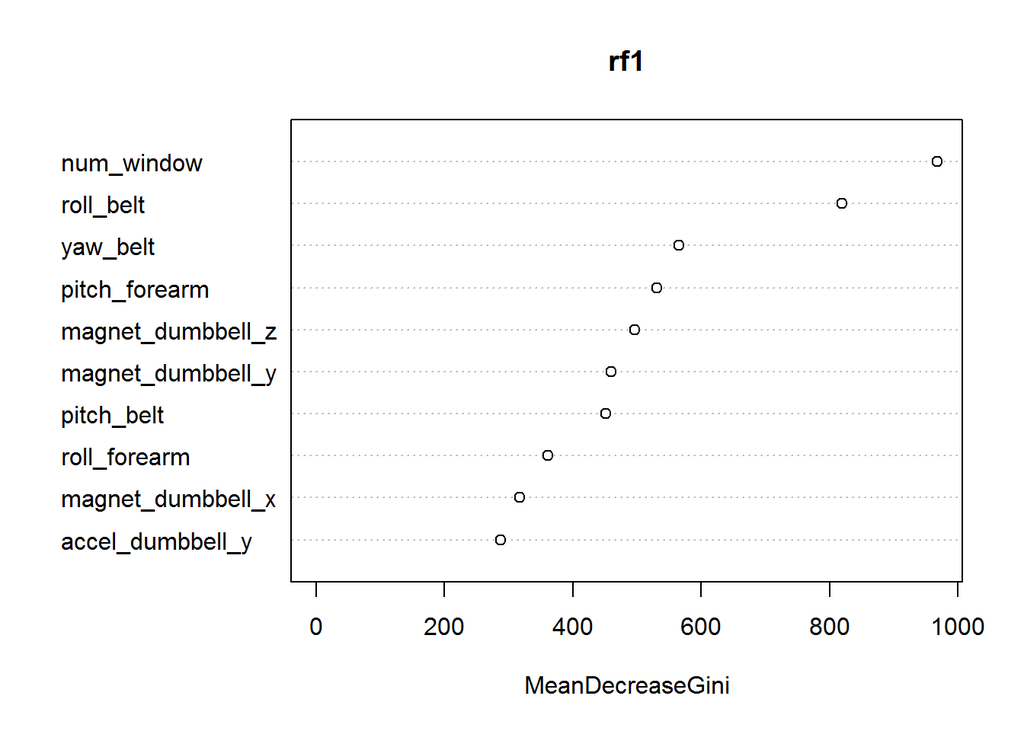

**Figure 1**. This plot depicts the ten most important variables in descending order of importance, beginning with num_window (the most important variable for prediction). The points along the x-axis (“MeanDecreaseGini”) give the numeric value of the variable importance.

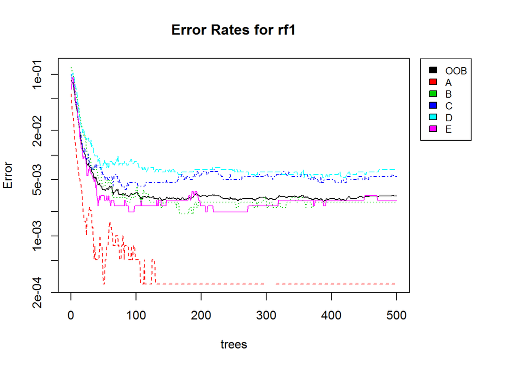

**Figure 2.** This plot shows the error rate (on a logarithmic scale) as a function of the number of trees in the random forest. The different colors correspond to to out-of-bag error (in black) and each classe factor (A, B, C, D, or E).